# GFA_Evaluation & GFA-Grünflächen-Configurator - Manual

Author

Gewerd Strauss

Published

rev.20.12.2023 07:03

# 1 GFA-Grünflächen-Configurator

*Overview*  
This program bundles several small utility scripts I wrote over the course of my internship. Major features include:

1. Generate the configuration-files and start-scripts required to run `GFA_Evaluation.R`. See the section on the main program.
2. A one-click function to create an *xlsx*- version of any *csv*-file which doesn’t exist as an *xlsx*-file yet. See the section on csv-conversion.
3. Easy GUI-aided method of mass-renaming ordered images into various groups. See the section on renaming images.

The respective sections go into further details; alternatively issues can be raised on the project’s [GitHub-Repository](https://github.com/Gewerd-Strauss/Gr-nfl-chen-Utilities/).  
The process of faceting is explained in detail here.  
The command line interface is explained in detail here.  
The logic behind which statistical tests are applied during daily Analyses is explained here.

## 1.1 Main Program

To make things easier, I will establish a few rules used throughout this section.  
Anytime text is formatted `like this (X)`, it refers to a button, editable field, drop-down menu, or in general a control on the GUI. The number at the end, here an `(X)` signifies which section of the GUI this control is located in. As an example, `csv2xlsx (4)` is the button used to convert *csv*-files to *xlsx*-files, located under *4. Auxiliary Utilities*.

### 1.1.1 Selecting a configuration

The main task of this program is to generate a suitable configuration file which can be used with the R-Script `GFA_Evaluation.R` bundled alongside this program. For details on its functioning, see documentation on GFA_Evaluation.R.

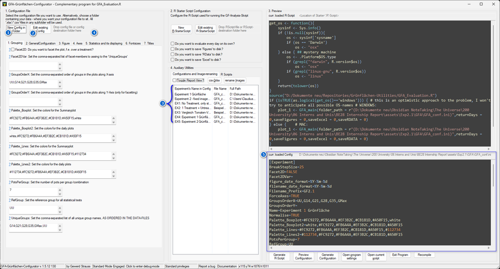

Figure 1: Various methods for loading in a configuration-file.

Configuration files can be handled by this program in several ways, annotated in figure 1:

1. `New Config in Folder (1)`  
   This allows you to create a config-file for a new project, in an arbitrary (but already existing) folder.
2. `Edit existing Config (1)`  
   This allows you to load an existing config file for editing
3. Double-clicking a configuration previously used under `Configurations and Image-renaming (4)`  
   This effectively works the same as Number 2. Note that entries starting with `EX` are example-files which will always remain at the bottom of the lists.
4. You may also drag and drop a config file onto the `greyed-out field (1)` to the right of those two buttons.

Under `curr. loaded Config (3)`, *the path to a configuration-file will be visible if the user has chosen a path already - by loading a config, or by manually selecting a config’s location when clicking `New Config in Folder`*.  
When *saving* or *previewing* a configuration, the program will attempt to validate the inputs given by the user. Certain inputs however cannot be validated with certainty by the program. In these cases, the user is asked to manually confirm or discard their choices. These popups differentiate between mild warnings (*yellow warning signs*) and severe warnings (*red x-crosses*). This depends on how severe a false decision may be, or how vital it is for `GFA_main()`’s functioning to have correct inputs.

### 1.1.2 Selecting and Editing an R-Script

To complement the config-files generated, the user may generate a barebones “starter”-R-Script which will call `GFA_main()`.

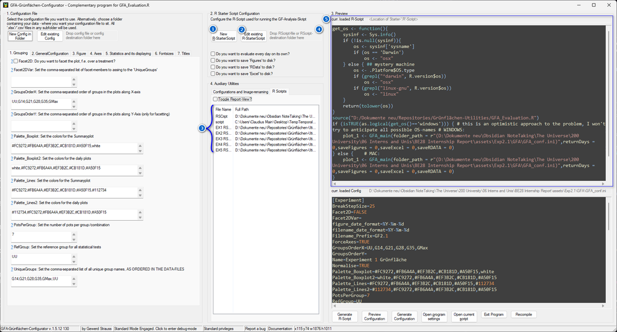

Figure 2: Various methods for loading in a RScript-file.

1. `New R-StarterScript (2)`  
   This allows you to create a new R-Script for a new project.
2. `Edit existing R-StarterScript (2)`  
   This allows you to load an existing R-Script for editing.
3. Double-clicking an R-Script previously used under `R Scripts (4)`  
   This effectively works the same as Number 2.
4. You may also drag and drop a config file onto the `greyed-out field (2)`[^1] to the right of those two buttons.

<sup>1</sup> Note that this is *not* the same greyed-out field that is used for dropping configurations.

Under `curr. loaded R-Script (3)`, *the contents of the currently loaded R-Script are visible*.  
If the field is empty, attempting to write to a file will result in the program asking the user to select an appropriate location.

#### Editing an existing R-Script

**Note**

This section deals with an advanced topic, and can be safely skipped otherwise. The tl;dr: modifying a script when overwriting it is possible. This should only be done with with intent and caution. **User-errors in this step are absolute and irreversible**.

The editing-capabilities of the program are *intentionally very limited*, for the sake of preventing users from inadvertently deleting data. The purpose here is merely to allow the use to update the fixed contents of their script via the AHK-program without discarding everything else they might have added to said script since.

When the user attempts to save their choices for an R-script to an existing R-File, the program will check if there are changes between the state you are trying to save and the currently saved file. If such changes are detected, the script is not immediately overwritten, but instead allows editing.  
The user is free to choose between the old and new version of the R-script file. Additionally, either version can be freely edited before selecting it. It should be mentioned that **the program will make no attempts at validating the resulting file**. It will also not backup the R-script beforehand. **As a result, any changes the user introduces during this step are absolute and irreversible**.

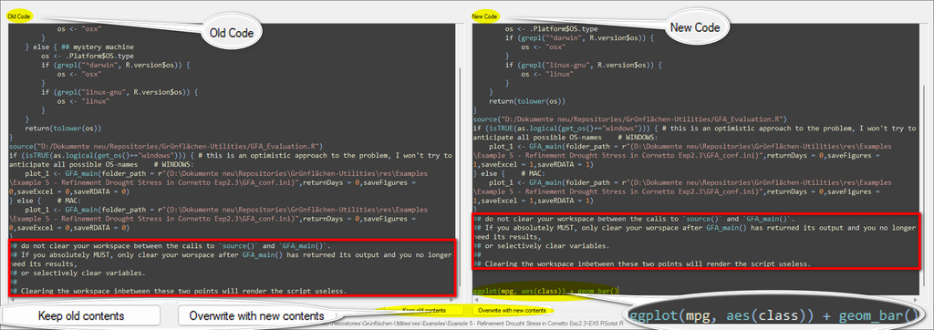

Figure 3: When overwriting an existing script, this window will appear. Notice the additional code added to the ‘New Code’-side, where the old script already ended at the bottom of the red box. Editing is allowed in both editing fields, but only the side you ultimately choose via either one of the two butons below will be used. Thus the intention behind this feature is to transplant large feature sets between an old script and its newer counterpart without loss.

### 1.1.3 Editing a configuration file

First off it makes sense to take a look at the example configurations and how the results of them look. Examples can be found under `<Location of Program>\res\Examples`. They are not meant to display sensible data, the data may be unrealistic. The intention of the reference files is mostly to give simple visualisation of a configuration. They also don’t showcase all potential cases, as those are just too many.

Configurations can be edited after being loaded (see section on config-selection).  
*If a configuration is loaded*, its path will be visible under `curr. loaded Config (3)`.  
Alternatively, the user can create a config file first.

### 1.1.4 Modifying the default settings or adding new settings

**Note**

This section deals with an advanced topic, and can be safely skipped otherwise. The tl;dr: modifying default values is easy. While possible, adding new settings should only be done with caution and is *not advised to go beyond the types of controls you see in the default GUI*.

As a closing remark on the main functionality, the author wants to note that adding new configuration keys is really *really* simple, as long as you understand the principle and the structure of the file. However, it is not recommended to be done “just like that”; users should be careful when doing so.  
The R-Script `GFA_Evaluation.R` is extensive, but there might be changes one will want to do, which will warrant changes to the default values of configuration-keys given.  
Additionally, the R-Script can be modified to allow for further control by using new and arbitrary configuration keys.  
Such changes might include adding additional configuration-keys.

*The default config*  
The Configurator-program loads the configuration keys it can edit from the file `<Location of Program>\INI-Files\GFC_DA.ini`. Each configuration key corresponds to a single line, **starting on the second line**. Every line below the first must either define a control, or begin with 2 spaces and at least one semicolon `;`, to define a comment which is not processed.

Every line after the first **must start** with exactly 2 spaces. Each line has the following principle structure:

```
  VariableName:<Control_Type>|Type:<Variable>|Default:<Default_Value>|String:<String>|TTIP:<String>|ctrlOptions:<String>|Tab3Parent:<String>|Link:<String>|LinkText:<?>|ConfigSection:<String>
  VariableName:<Control_Type>|Type:<Variable>|Default:<Default_Value>|String:<Text written in the GUI to explain its function>|TTIP:<Contents of the tooltip when hovering the control or its '?'|ctrlOptions:<String>|Tab3Parent:<Name of tab which should contain this Control>|Link:<For online documentation, use this to link to where you store direct documentation on its value. Most likely irrelevant for you, as you cannot easily edit the Git-Repository without further notice.>|LinkText:<?>|ConfigSection:<The section of the configuration-list, e.g. 'Experiment' for 'ini$Experiment', 'FontSizes' for 'ini$FontSizes',...>
```

Example:

```
Experiment::blank
    ;; 1. Grouping
    PotsPerGroup:Edit|Type:Integer|Default:7|String:"Set the number of pots per group/combination"|TTIP:[Facet2D==TRUE]\nHere, combination is a combination of a member of 'UniqueGroups' and a member of 'Facet2DVar'|ctrlOptions:number|Tab3Parent:1. Grouping|Link:https://{GH-Repo}#{Parameter}|Linktext:?|ConfigSection:Experiment
    UniqueGroups:Edit|Type:String|Default:G14,G21,G28,G35,G42,UU|String:"Set the comma-separated list of all unique group names"|TTIP:If you set 'Facet2D' to TRUE, this must have as many entries as 'Facet2DVar'|Tab3Parent:1. Grouping|Link:https://{GH-Repo}#{Parameter}|Linktext:?|ConfigSection:Experiment
    GroupsOrderX:Edit|Type:String|Default:UU,G14,G21,G28,G35,G42|String:"Set the comma-separated order of groups in the plots along X-axis"|TTIP:Order the Groups along the X-Axis. Groups are ordered left to right|Tab3Parent:1. Grouping|Link:https://{GH-Repo}#{Parameter}|Linktext:?|ConfigSection:Experiment
    GroupsOrderY:Edit|Type:String|Default:|String:"Set the comma-separated order of groups in the plots along Y-Axis (only for faceting)"|TTIP:[Facet2D==TRUE]\nOrder the Groups along the Y-Axis. Groups are ordered top to bottom.|Tab3Parent:1. Grouping|Link:https://{GH-Repo}#{Parameter}|Linktext:?|ConfigSection:Experiment
    RefGroup:Edit|Type:String|Default:UU|String:"Set the reference group for all statistical tests"|TTIP:\n[Facet2D==FALSE]\nFor a normal plot, this must be a member of 'UniqueGroups'\n\n[Facet2D==TRUE]\nFor a facetted plot, this must be a combination of 1 member of 'Facet2DVar' and 'UniqueGroups', separated by a dot (.).\nThe order is always '[UniqueGroups_Member].[Facet2DVar_Member]'\nExample:\n'Ungestresst.Unbehandelt'|Tab3Parent:1. Grouping|Link:https://{GH-Repo}#{Parameter}|Linktext:?|ConfigSection:Experiment
    Facet2D:Checkbox|Type:boolean|Default:0|String:"Do you want to facet the plot, f.e. over a treatment?"|TTIP:Clarification: faceting here refers to the segmentation of the plots along the Y-Axis, NOT along the X-Axis.\nFor segmenting along the X-Axis, refer to 'UniqueGroups' and 'GroupsOrderX'.|Tab3Parent:1. Grouping|Link:https://{GH-Repo}#{Parameter}|Linktext:?|ConfigSection:Experiment
    Facet2DVar:Edit|Type:String|Default:""|String:"Set the comma-separated list of facet-members to assing to the 'UniqueGroups'"|TTIP:[Facet2D==TRUE]\nClarification: The entries you specified for 'UniqueGroups' must each match a single entry in this list as well|Tab3Parent:1. Grouping|Link:https://{GH-Repo}#{Parameter}|Linktext:?|ConfigSection:Experiment
    ;;
    Palette_Boxplot:Edit|Type:String|Default:"yellow","orange","orangered","red","darkred","black","white"|String:Set the colors for the Summaryplot|TTIP:Colors are assigned regardless of order of the plots, and always in the following order:\nLeft to right, Top to bottom\n\nThis set of colors is responsible for the overview plot|Tab3Parent:1. Grouping|Link:https://{GH-Repo}#{Parameter}|ctrlOptions:w400|Linktext:?|ConfigSection:Experiment
    Palette_Lines:Edit|Type:String|Default:"yellow","orange","orangered","red","darkred","black","black"|String:Set the colors for the Summaryplot|TTIP:Colors are assigned regardless of order of the plots, and always in the following order:\nLeft to right, Top to bottom\n\nThis set of colors is responsible for the overview plot|Tab3Parent:1. Grouping|Link:https://{GH-Repo}#{Parameter}|ctrlOptions:w400|Linktext:?|ConfigSection:Experiment
    Palette_Boxplot2:Edit|Type:String|Default:"white","yellow","orange","orangered","red","darkred","black"|String:Set the colors for the daily plots|TTIP:Colors are assigned regardless of order of the plots, and always in the following order:\nLeft to right, Top to bottom\n\nThis set of colors is responsible for the daily plots|Tab3Parent:1. Grouping|Link:https://{GH-Repo}#{Parameter}|ctrlOptions:w400|Linktext:?|ConfigSection:Experiment
    Palette_Lines2:Edit|Type:String|Default:"black","yellow","orange","orangered","red","darkred","black"|String:Set the colors for the daily plots|TTIP:Colors are assigned regardless of order of the plots, and always in the following order:\nLeft to right, Top to bottom\n\nThis set of colors is responsible for the daily plots|Tab3Parent:1. Grouping|Link:https://{GH-Repo}#{Parameter}|ctrlOptions:w400|Linktext:?|ConfigSection:Experiment
    ;;
    ;; 2. General Configuration
```

#### Modifying Settings

Modification would primarily include changing the `Default:XX`-value or adding/removing options for Choice-Controls (called `DropDown`/`DDL` and `ComboBox`).  
The author does not recommend modifying anything for existing controls besides their Default or Choices.  
For `DDL`s and `ComboBox`es, their existing choices are set via the `ctrlOptions:`-argument. `DDL`s do only allow options set under `ctrlOptions`, while `ComboBox`es also allow the user to enter their own values, similar to a normal edit field.

#### Adding Settings

In principle, the functionality of the R-Script can be expanded quite easily, by first creating the R-Code you wan to add, and then making it conditional based on a cofiguration-value. After the R-script side of things is finished, the configuration-value can then be added to the GUI.  
There are a couple things to note:

- To define a boolean/logical (`TRUE`/`FALSE`), use a `checkbox`-control
- To define an integer, use an `Edit`-control, and set `ctrlOptions:number`
- To define a number, use an `Edit`-control, and set `ctrlOptions:gcheckDecimalsOnEdit`
- Generally, the best way is to understand what type of value you need in R, then look for an example that already defines such, and then adapt the variable name and control/tooltip texts/etc. Variables currently used by the R-Script are
  - boolean/logical (e.g. `Facet2D`)
  - float/numeric (e.g. `FontSize_PValue`)
    - integer (e.g. `PotsPerGroup`)
  - String (for anything that doesn’t fit the types above)
- Custom controls should only replicate what is seen in the GUI so far, as ther eis no validation for more-exotic things - not without modifying the code itself.
  - e.g. if you want to allow a range of integers, see the definition for `Theme`
- After adding a config setting in the AHK-program, the user can go ahead and implement its functionality in the R-Code. For doing so, please refer to how configuration keys are used in the existing script. It is recommended wrap such functionality into a conditional `if`-statement which checks if the configuration key exists first, so that old configurations without that key remain functional:

```r
if (hasName(ini$Fontsizes,"Fontsize_PValue")) {
    pval_size <- as.numeric(ini$Fontsizes$Fontsize_PValue)
} else {
    pval_size <- 2.5
}
```

### 1.1.5 Faceting

Faceting is a bit complex in the scope of this program. It is **absolutely recommended to experiment with the bundled faceting example** to get acquainted.  
To begin, it is mandatory to understand that **the data-layer and the aesthetics for said data are unrelated**. As a consequence, reordering the order of groups along the x- or y-axis in a plot will not keep the colors to their **former groups/interactions**, instead will keep the colors **locked in place**. You assign colors to a specific *facet of the plot*, **not** to the data that “happens” to be in that position.  
Colors are filled into the facets with the following rules:

1. Left to Right
2. Top to Bottom

As an example, take the following example set of facets:

| Panel Top Left | Panel Top Middle | Panel Top Right |
| --- | --- | --- |
| Panel Bottom Left | Panel Bottom Middle | Panel Bottom Right |

If you give the following colors for `Palette_Boxplot`

```
red,yellow,orange,green,blue,violet
```

you will receive the following coloring:

| red | yellow | orange |
| --- | --- | --- |
| green | blue | violet |

*With that out of the way, the actual guide*:  
You typically facet your plot to compare a treated set of groups to untreated complements. As a result, you will typically have plants belonging to either of the following 4 categories:

1. Stressed, Untreated
2. Stressed, Treated
3. Unstressed,Untreated
4. Unstressed, Treated

And each image taken belongs to either of these four categories. Obviously there may be various stress or treatment groups.  
To create a facetted plot, you plot one of these characteristics on the X-axis (f.e. the Stress applied), and the other characteristic on the Y-Axis (f.e. the treatment applied).  
Consequently, each column of data loaded in will be assigned a combination of both options. **When faceting**, `UniqueGroups` acts as one of these two descriptors and gets plotted on the X-Axis. Therefore, it wil contain only one type of descriptor (you typically plot Stress on X,/`UniqueGroups` and Treatment on Y/`Facet2DVar`)

As this can become complex, the following procedure is *recommended*:

**Step-By-Step-Guide to populating section ‘1. Grouping’ when faceting.**

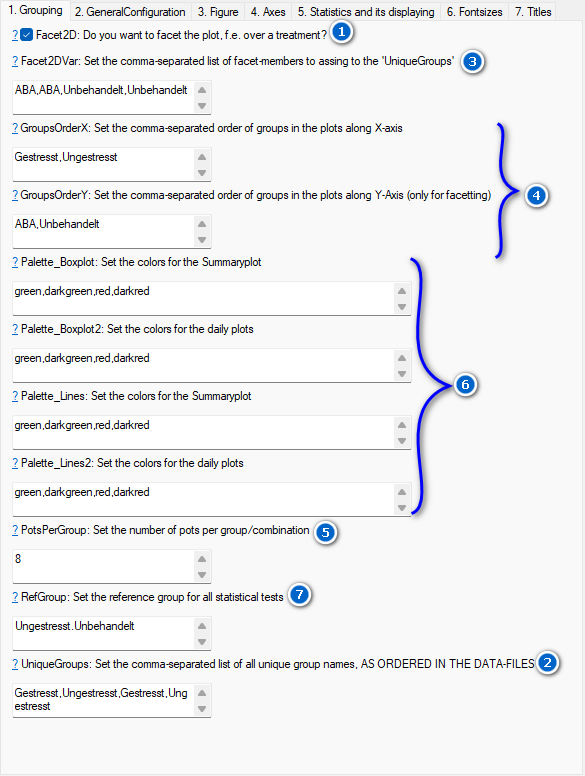

Order of Operations for setting up faceting for an experiment.

1. Tick `Facet2D`.
2. Define `UniqueGroups`: As this is a facetted plot, it will only contain one of the two descriptors. Typically *Stress*. Thus, it will contain repetitions.
3. Define `Facet2DVar`: As this is a facetted plot, it will only contain one of the two descriptors. Typically *Treatment*. Thus, it will contain repetitions.
4. Define `GroupsOrderX` & `GroupsOrderY`, which must be a single group out of `UniqueGroups` & `Facet2DVar` respectively.  
   These “ordering” entries control the order, left-to-right, top-to-bottom,, in which facets are populated with data, by ordering the data across `data$Groups` and `data$Facet` in their order. This is responsible for deciding the position of an interaction (e.g. `Unstressed.Untreated`) on the plot.
5. Define `GroupsOrderXFacetingDaily` to control the order of facets (left-to-right) in the daily plots. Entries must be a combination between a member of `UniqueGroups` and `Facet2DVar`, separated by a dot (`.`), starting with the member of `UniqueGroups`. If `Facet2DVar=Gestresst,Ungestresst,Gestresst,Ungestresst` & `UniqueGroups=ABA,ABA,Kontrolle,Kontrolle`, then `GroupsOrderXFacetingDaily` may be `Kontrolle.Gestresst,ABA.Gestresst,Kontrolle.Ungestresst,ABA.Ungestresst`.
6. Define `PotsPerGroup`. Pretty self-explanatory. The number is assigned **per interaction**, so the following must hold true:
   $$\begin{align*}
   \frac{\text{Rows in datafiles}}{\text{PotsPerGroup}\times \text{N}_{\text{Facet2DVar}}}=1
   \end{align*}$$
7. Define the colors under `Palette_Boxplot`,`Palette_Boxplot2`,`Palette_Lines`,`Palette_Lines2` respectively. Keep the order along the X- & Y-axis respectively and assign colors.
8. Define `RefGroup`. When faceting, this must contain a *single interaction*, a single combination between a member of `UniqueGroups` & `Facet2DVar`, separated by a dot (`.`), starting with the member of `UniqueGroups`. For the previous example for `GroupsOrderXFacetingDaily`, a suitable `RefGroup` may be `Kontrolle.Ungestresst`.

**Flipping axes when faceting**

The syntax for `RefGroup` is `%UniqueGroups%.%Facet2DVar%`.  
If your groups are defined as follows, with `Kontrolle/ABA` on the X-axis of the summary-plot:

```r
Facet2DVar=Gestresst,Ungestresst,Gestresst,Ungestresst
GroupsOrderX=Kontrolle,ABA
GroupsOrderY=Ungestresst,Gestresst
GroupsOrderXFacetingDaily=Kontrolle.Gestresst,ABA.Gestresst,Kontrolle.Ungestresst,ABA.Ungestresst
UniqueGroups=ABA,ABA,Kontrolle,Kontrolle
```

then a potential valid `RefGroup` is:

```r
RefGroup=Kontrolle.Ungestresst
```

If you however flip around the groups so that `Ungestresst/Gestresst` is plotted on the X-axis of the summary-plot:

```r
Facet2DVar=ABA,ABA,Kontrolle,Kontrolle
GroupsOrderX=Ungestresst,Gestresst
GroupsOrderY=Kontrolle,ABA
GroupsOrderXFacetingDaily=Gestresst.ABA,Gestresst.Kontrolle,Ungestresst.ABA,Ungestresst.Kontrolle
UniqueGroups=Gestresst,Ungestresst,Gestresst,Ungestresst
```

you need to reverse the order for your Ref-Group as well:

```r
RefGroup=Ungestresst.Kontrolle
```

### 1.1.6 Controlling Y-Limits

By default, the script will adjust the upper y-limits if they lie within 5% of the maximum y-value in the dataset. The intention behind this is to keep sufficient space at the top of the plot to insert statistical information (e.g. `n=3`/`p=0.0323`).  
However, there are scenarios where you know the upper limit of your data and want to force a specific limit above that. In this scenario, the user may set `strictLimitsValidation` or `strictLimitsValidation_Daily` (for the summary- and daily-plots respectively) while calling `GFA_main()`.  
The below pseudo-code displays which steps are not performed when setting these respective flags to `TRUE`:

```r
if (isFALSE(as.logical(strictLimitsValidation))) {
    while ((Limits[[2]] - (Limits[[2]] * 0.05)) < max(as.vector(Dataset$Y-value))) {
        Limits[[2]] <- Limits[[2]] + breaks$BreakStepSize
        breaks$breaknumber <- breaks$breaknumber + 1
    }
}
```

Keep in mind that this is *not* a configuration-key, but a parameter of the call to `GFA_main()`

### 1.1.7 Controlling which data is plotted

Starting with version `1.5.41`, the user may select arbitrary data columns of the data input files to be processed. It is not possible to plot two or more different columns together.  
The same processing steps are performed, regardless of which data column is chosen.

### 1.1.8 Configuration Options for the Main Program

The configuration options which will directly influence the functionality of the GFA-Grünflächen-Configurator are listed below. The default values are set as a suggestion; and these options are mostly for more niche tweaks. However, particularly the option `INI_Encoding` should be approached with care, as it can have unexpected influences if the user is not careful.

| Option | Explanation |
| --- | --- |
| AlwaysOnTop | Set the main GUI to always be in front of other windows. You can still hide the program via the tray-menu. |
| SizeSetting | Determine how to scale the GUI. You may choose to scale it for either a 1080p- or a 1440p-display, or to calculate the size based on the dimensions of the current display |
| ConfigHistoryLimit | Define how many configuration- and R-files you want to keep in the history-tabs. If the threshold is crossed, the oldest files will be removed from the respective list. |
| bRunAsAdmin | Control if you want to run the program with administrator-privileges. This is usually not required, but is a recommended first step when you encounter issues with generating files |
| GFA_Evaluation_InstallationPath | Define the location of the ‘GFA_Evaluation.R’-script. By default, the program bundled alongside this script will be used. |
| UseRelativeConfigPaths | When generating an R-Script, by default the program will assume that the configuration-file and the R-Script will be located in the same folder. |
| INI_Encoding | Select the file-encoding for the configuration file. It is not recommended to be changed from its default ‘UTF-16’ unless you encounter severe issues with data-corruption in configuration files. |
| Custom_R_Script_Template | Select a template R-script file to be used as a template when generating the R-Script for an analysis. The template must fulfill certain requirements. For more details, refer to the setting in the pro… |
| CheckUpdatesOnScriptStart | Should the program check for updates when it starts? Refer to |

### 1.1.9 Status Bar

The status-bar gives information on a variety of things, and allows interaction for various purposes. To trigger each section, double-click upon it.

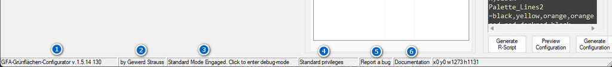

Overview on the program’s status-bar.

1. Check for updates. This can also be done automatically upon startup.
2. About the program. Gives information on code used and various relevant links. Allows bug-reports and direct-links to the project’s repository.
3. Toggle between Debug- and Default mode. Debug-mode allows editing hidden configuration keys via the normal settings-GUI. While most hidden configuration keys are not supposed to be edited by the user, this method can be used to remove items from the Configuration- and RScript-Histories.
4. If the program was not started in administrator-mode, double-clicking this will allow you to restart the program elevated to administrator-orivileges. To leave administrator-privileges, exit the program and start it again manually.
5. Direct-Link for reporting bugs.
6. Direct-Link to this online-documentation.

### 1.1.10 Tray Menu

Right-clicking the program’s tray-icon will gives access to various auxiliary utilities which cannot be sensibly implemented into the main GUI itself.

1. `Restore default config` - delete the currently active settings for the program
2. `Restart as Administrator` - restart the program and ask for administrator-privileges. See here for more details.
3. `Reload` - reloads the program, discarding any changes made to any currently loaded and unsaved files.
4. `Exit Program` - exits the program while discarding any changes made to any currently loaded and unsaved files.
5. `Show GUI` shows the GUI if it is not active.
6. `Copy GFA_Evaluation-Path` - copy the path to `GFA_Evaluation.R` defined in the settings to your clipboard, formatted to be used with R’s `source()`-function.
7. `Open CMD` - open the command line at the `GFA_Evaluation-Path`-directory. Intended as an easier setup for using the script as a command-line utility. For more information on the CLI, see here.

## 1.2 csv2xlsx

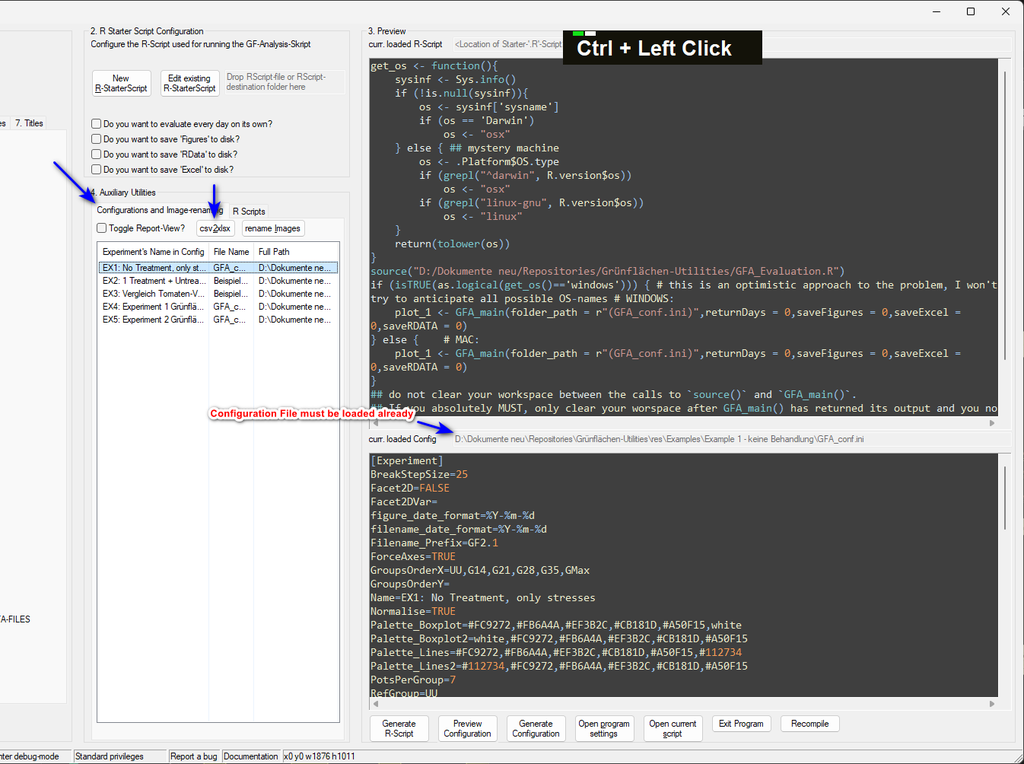

Convert ‘csv’-files in any subfolder of the currently loaded configuration to ‘xlsx’

After selecting a configuration file (see here), you may use the button `csv2xlsx (4)` to run the *csv-to-xlsx*-converter embedded into the program. It will parse through all _*.csv_-files in any subfolder of the config’s location, check if there is a xlsx-equivalent present, and create it if it is not.

**Note**

This program *will cease to function* if the csv’s are not delimited using either `,` or `;`.  
The program will

1. replace the cell-delimiter (`,` or `;`) with `;`
2. replace dots `.` with `,`
3. save this transformed version **to the csv-file**, effectively overwriting it.
4. Afterwards, it will create an xlsx-copy.

**Important**

**This functionality requires the program Excel to be installed on the user’s machine, as it takes advantage of Excel’s *ComObject*-Interface to do its work.**

*Program Configuration options*:  
As with all *program*-configuration options, these affect the behaviour of the Configurator-Program, **not** the R-Script.  
Options can be accessed by pressing *Alt+P* on the Configurator’s main window. It is not recommended to modify the raw config files of this program by hand.[^2]

<sup>2</sup> You can, obviously. It is just very easy to disrupt or destroy data if you do not know how AutoHotkey handles config files, and more importantly how this program itself handles them. Just use the GUI please.

| Option | Explanation |
| --- | --- |
| / | / |

## 1.3 Rename images

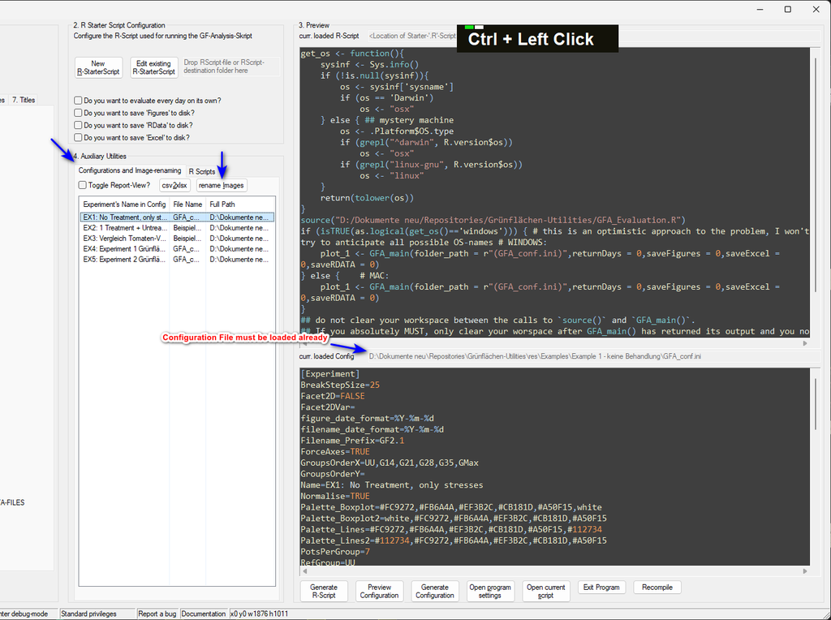

Rename image-files using the groups defined in the currently loaded configuration.

*Program Configuration options*:  
After selecting a configuration file (see here), you may use the button `rename Images (4)` to run the *image-renamer* embedded into the program.  
The program will use the currently loaded configuration to retrieve data required, namely *the number of pots per group & groups names*. These variables can be changed before submitting. The user can then choose a **folder containing images they want to rename**. The folder must not contain subfolders which also contain images, or those will also be considered.

Upon submission, the program will open a preview in which the user can check that each image was associated with its correct name; then submit to rename the images (figure 4).

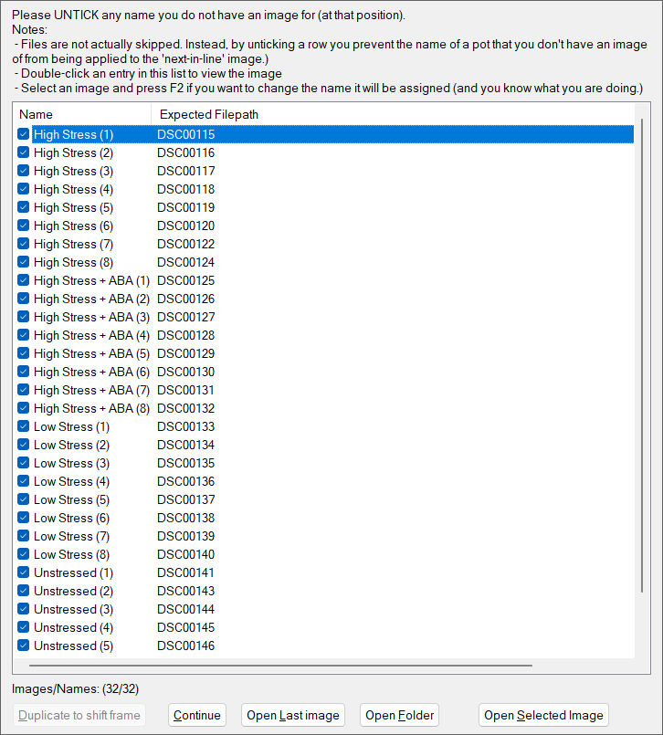

Figure 4: Image Renamer: Match expected new name (left side) with their respective file (right side). You can double-click a row to open the image in your default app, to inspect if the matching is correct.

Images are never renamed in-place, instead a set of working copies is made which get renamed instead. They will be located in a *GFAR_WD*-subfolder of the initially chosen directory, alongside a text file associating original filenames with their renamed counterparts.  
As with all *program*-configuration options, these affect the behaviour of the Configurator-Program, **not** the R-Script.  
Options can be accessed by pressing *Alt+P* on the Configurator’s main window. It is not recommended to modify the raw config files of this program by hand.[^3]

<sup>3</sup> You can, obviously. It is just very easy to disrupt or destroy data if you do not know how AutoHotkey handles config files, and more importantly how this program itself handles them. Just use the GUI please.

| Option | Explanation |
| --- | --- |
| filetype | Select if the script should consider *JPG*- or *PNG*-files for renaming. |
| PutFilesOnClipboard | Do you want to have the renamed images put on your clipboard at the end? Suggested if you need to move them all to a different computer. |
| CopyFiles | Select if you want to copy `Ctrl+C` the files to your clipboard. Uncheck if you want to cut `Ctrl+X` them instead |
| CopyParentDirectory | Select if you want to copy/cut the parent directory, instead of all files. Generally suggested to ease batch-renaming of multiple sets at once. |

**What to do if you are missing an image in a group or have less images than name-permutations**

In cases where a certain group has fewer images than the other - as could be the case if you loose a single pot at some point due to damage - simply select the image of the **NEXT** pot and create a copy by pressing `Duplicate to shift frame`. Refer to figures (5,6 & 7) for visual aid on the process outlined in this section.

Refer to figure 5.  
If we assume that the image for `G14D2` and `G14D3` are missing *initially*, aka in the image above the file `DSC06473` actually contains the image of `G14D4`, select `DSC06473` and press on `Duplicate to shift frame`.

If you need to duplicate the same image more than once, **any duplications required to fill subsequent gaps** must be made of the **padded** image. In this example, if you press the button once, you would get an entry with the expected filepath of `DSC06473 (padding)`. As you need to pad twice, you then select the entry of `DSC06473 (padding)` and repeat the process. If you were to select `DSC06473`, duplicating it again will not work.  
If you would want to bridge a 3-image wide gap, you would duplicate `DSC06473` to `DSC06473 (padding)`, then `DSC06473 (padding)` to `DSC06473 (padding) (padding)`, and finally `DSC06473 (padding) (padding)` to `DSC06473 (padding) (padding) (padding)`.

The result will look something like this:

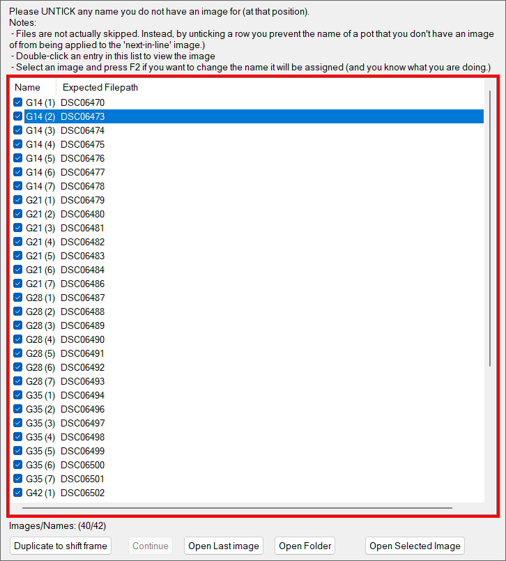

Figure 5: Images for G14D2 and G14D3 are missing (notice that DSC06470 is followed by DSC06473). We need to bridge the gap to avoid a frameshift.

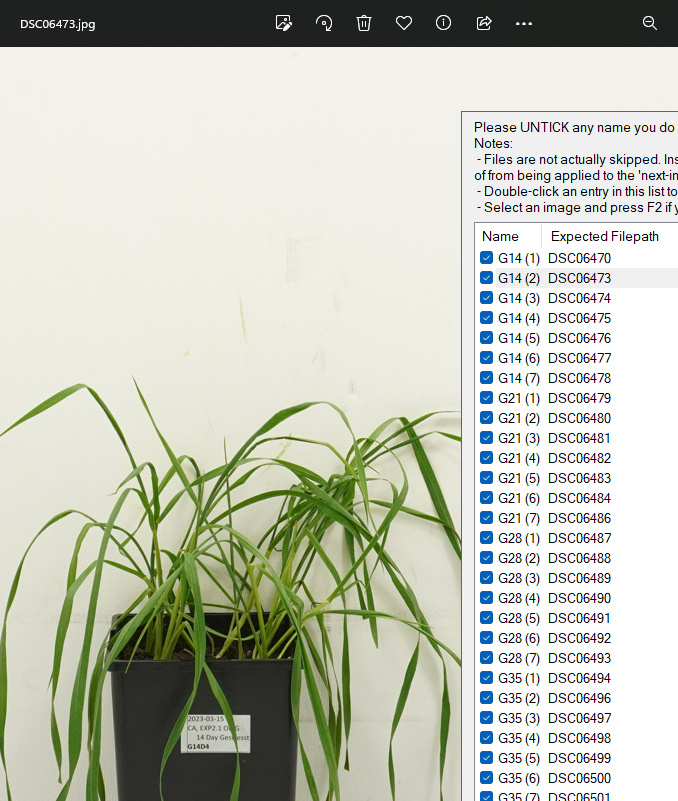

Figure 6: Closeup of ‘DSC06473’ showing that it is indeed the image of Pot ‘G14D4’

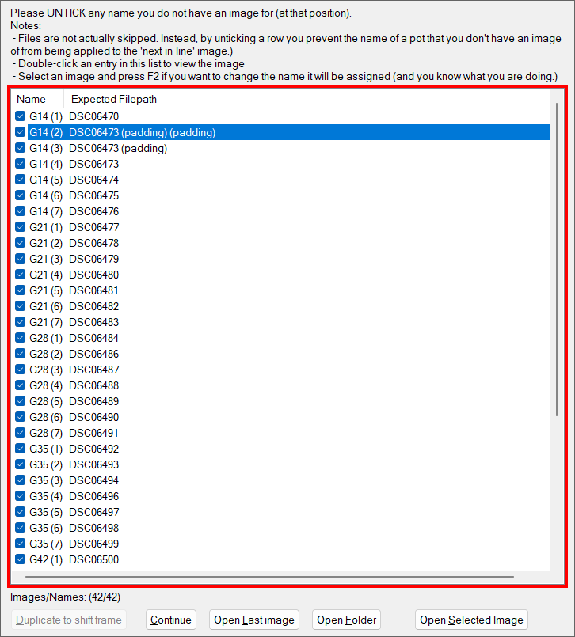

Figure 7: Using two padded images for the missing entries ‘G14D2-G14D3’ to overcome the ‘frameshift’ at these ‘positions’.

Example:

You have a group of plants which get watered at half the normal volume for 14 days, and every group has 7 pots.

The pot G14D4 (14 Days at reduced water supply, then back up to normal) was removed because it got dropped a day before.

In this case, all groups have seven images, but the G14-Group only has six. Thus, imagine you have the following images to work with:

| Number | Filename | intended file name/label as seen on pot | file name without frame shift |
| --- | --- | --- | --- |
| 1 | DSC10111.JPG | `G14D1` | `G14D1` |
| 2 | DSC10112.JPG | `G14D2` | `G14D2` |
| 3 | DSC10113.JPG | `G14D3` | `G14D3` |
| 4 | DSC10114.JPG | `G14D5` | `G14D4` |
| 5 | DSC10115.JPG | `G14D6` | `G14D5` |
| 6 | DSC10116.JPG | `G14D7` | `G14D6` |

To prevent this, create a copy of `DSC10113` - it is important that you copy the image of the pot *immediately before the one that is missing*:

| Number | Filename | intended file name/plant label as seen on pot | file name with frame shift |
| --- | --- | --- | --- |
| 1 | DSC10111.JPG | `G14D1` | `G14D1` |
| 2 | DSC10112.JPG | `G14D2` | `G14D2` |
| 3 | DSC10113.JPG | `G14D3` | `G14D3` |
| 4 | DSC10113 - Copy.JPG | `<Placeholder for the missing pot G14D4>` | `<Placeholder for the missing pot G14D4>` |
| 5 | DSC10114.JPG | `G14D5` | `G14D5` |
| 6 | DSC10115.JPG | `G14D6` | `G14D6` |
| 7 | DSC10116.JPG | `G14D7` | `G14D7` |

As the script will read images in the folder based on their name, this method ensures the gap is filled appropriately.

### 1.3.1 How to deal with varying group sizes

Sometimes you have experiments with several varying group sizes, e.g. a drought stress setup on two axes - stressed vs unstressed, and ABA-treated vs non-treated, which may not have the same group sizes:

| Stress/Treatment | / | ABA |
| --- | --- | --- |
| Stress | Stress (8) | Stress-ABA (5) |
| UU | UU (8) | UU-ABA (5) |

In this case, you would set `Stress,Stress-ABA,UU,UU-ABA` as `groups`, and `8,5,8,5` as group sizes (see figure 8).

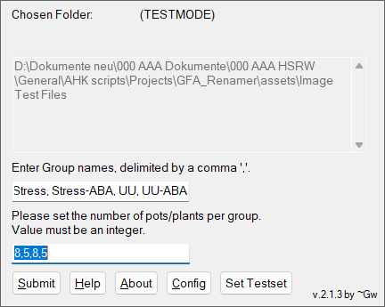

Figure 8: Setting groups of varying sizes.

### 1.3.2 Image-Renamer Test-Datasets

Starting with version `1.5.46`, this program will download 2 sets of images when first initialised. If the machine does not have internet access, this action is postponed until internet access is available.  
Data is downloaded from the following two gists:

- [Full Test Dataset](https://gist.github.com/Gewerd-Strauss/41513a345dc601353cd5a8a46227276b)
- [Partial Test Dataset](https://gist.github.com/Gewerd-Strauss/410af64eed560abfbae8a436d141b36b)

They contain sets of 30 & 32 images which are of plants for the Example `EX5: Experiment 2 Grünfläche`. As a result, the user may load this configuration-file to obtain a suitable set of file names.  
The partial dataset exists to showcase how to deal with missing images.

## 1.4 Parameter Quick-Reference

This section serves as a quick reference for modifying an existing config-file without necessarily opening the program, and assumes the user is informed about the basic functionality of the parameters they alter.  
If unsure, it is recommended to modify config files via this script - although that is only possible on Windows.  
For further, and particularly usage-dependent information, see the tooltip information on each parameter.

### 1.4.1 Grouping

#### `Facet2D`

| Parameter | `Facet2D` [Section:`Experiment`] |
| --- | --- |
| Value | `FALSE` |
| Default | `0` |
| Type | `boolean` |
| Options | `TRUE/FALSE` |
| Instruction | `Facet2D: Do you want to facet the plot, f.e. over a treatment?` |
| Elaboration | `Clarification: faceting here refers to the segmentation of the plots along the Y-Axis, NOT along the X-Axis.\nFor segmenting along the X-Axis, refer to 'UniqueGroups' and 'GroupsOrderX'.` |

#### `Facet2DVar`

| Parameter | `Facet2DVar` [Section:`Experiment`] |
| --- | --- |
| Value | `/` |
| Default | `/` |
| Type | `String` |
| Options | `/` |
| Instruction | `Facet2DVar: Set the comma-separated list of facet-members to assing to the 'UniqueGroups'` |
| Elaboration | `[Facet2D==TRUE]\nClarification: The entries you specified for 'UniqueGroups' must each match a single entry in this list as well` |

#### `GroupsOrderX`

| Parameter | `GroupsOrderX` [Section:`Experiment`] |
| --- | --- |
| Value | `UU,G14,G21,G28,G35,G42` |
| Default | `UU,G14,G21,G28,G35,G42` |
| Type | `String` |
| Options | `/` |
| Instruction | `GroupsOrderX: Set the comma-separated order of groups in the plots along X-axis` |
| Elaboration | `Order the Groups along the X-Axis. Groups are ordered left to right` |

#### `GroupsOrderY`

| Parameter | `GroupsOrderY` [Section:`Experiment`] |
| --- | --- |
| Value | `/` |
| Default | `/` |
| Type | `String` |
| Options | `/` |
| Instruction | `GroupsOrderY: Set the comma-separated order of groups in the plots along Y-Axis (only for faceting)` |
| Elaboration | `[Facet2D==TRUE]\nOrder the Groups along the Y-Axis. Groups are ordered top to bottom.` |

#### `Palette_Boxplot`

| Parameter | `Palette_Boxplot` [Section:`Experiment`] |
| --- | --- |
| Value | `yellow,orange,orangered,red,darkred,black,white` |
| Default | `yellow,orange,orangered,red,darkred,black,white` |
| Type | `String` |
| Options | `w400/` |
| Instruction | `Palette_Boxplot: Set the colors for the Summaryplot` |
| Elaboration | `Colors are assigned regardless of order of the plots, and always in the following order:\nLeft to right, Top to bottom\n\nThis set of colors is responsible for the overview plot` |

#### `Palette_Boxplot2`

| Parameter | `Palette_Boxplot2` [Section:`Experiment`] |
| --- | --- |
| Value | `white,yellow,orange,orangered,red,darkred,black` |
| Default | `white,yellow,orange,orangered,red,darkred,black` |
| Type | `String` |
| Options | `w400/` |
| Instruction | `Palette_Boxplot2: Set the colors for the daily plots` |
| Elaboration | `Colors are assigned regardless of order of the plots, and always in the following order:\nLeft to right, Top to bottom\n\nThis set of colors is responsible for the daily plots` |

#### `Palette_Lines`

| Parameter | `Palette_Lines` [Section:`Experiment`] |
| --- | --- |
| Value | `yellow,orange,orangered,red,darkred,black,black` |
| Default | `yellow,orange,orangered,red,darkred,black,black` |
| Type | `String` |
| Options | `w400/` |
| Instruction | `Palette_Lines: Set the colors for the Summaryplot` |
| Elaboration | `Colors are assigned regardless of order of the plots, and always in the following order:\nLeft to right, Top to bottom\n\nThis set of colors is responsible for the overview plot` |

#### `Palette_Lines2`

| Parameter | `Palette_Lines2` [Section:`Experiment`] |
| --- | --- |
| Value | `black,yellow,orange,orangered,red,darkred,black` |
| Default | `black,yellow,orange,orangered,red,darkred,black` |
| Type | `String` |
| Options | `w400/` |
| Instruction | `Palette_Lines2: Set the colors for the daily plots` |
| Elaboration | `Colors are assigned regardless of order of the plots, and always in the following order:\nLeft to right, Top to bottom\n\nThis set of colors is responsible for the daily plots` |

#### `PotsPerGroup`

| Parameter | `PotsPerGroup` [Section:`Experiment`] |
| --- | --- |
| Value | `7` |
| Default | `7` |
| Type | `Integer` |
| Options | `number/` |
| Instruction | `PotsPerGroup: Set the number of pots per group/combination` |
| Elaboration | `[Facet2D==TRUE]\nHere, combination is a combination of a member of 'UniqueGroups' and a member of 'Facet2DVar'` |

#### `RefGroup`

| Parameter | `RefGroup` [Section:`Experiment`] |
| --- | --- |
| Value | `UU` |
| Default | `UU` |
| Type | `String` |
| Options | `/` |
| Instruction | `RefGroup: Set the reference group for all statistical tests` |
| Elaboration | `\n[Facet2D==FALSE]\nFor a normal plot, this must be a member of 'UniqueGroups'\n\n[Facet2D==TRUE]\nFor a facetted plot, this must be a combination of 1 member of 'Facet2DVar' and 'UniqueGroups', sepa… |

#### `UniqueGroups`

| Parameter | `UniqueGroups` [Section:`Experiment`] |
| --- | --- |
| Value | `G14,G21,G28,G35,G42,UU` |
| Default | `G14,G21,G28,G35,G42,UU` |
| Type | `String` |
| Options | `/` |
| Instruction | `UniqueGroups: Set the comma-separated list of all unique group names` |
| Elaboration | `If you set 'Facet2D' to TRUE, this must have as many entries as 'Facet2DVar'` |

### 1.4.2 GeneralConfiguration

#### `Debug`

| Parameter | `Debug` [Section:`General`] |
| --- | --- |
| Value | `FALSE` |
| Default | `0` |
| Type | `boolean` |
| Options | `TRUE/FALSE` |
| Instruction | `Debug: Do you want to print debug information?` |
| Elaboration |  |

#### `filename_date_format`

| Parameter | `filename_date_format` [Section:`Experiment`] |
| --- | --- |
| Value | `%d.%m.%Y` |
| Default | `%d.%m.%Y` |
| Type | `String` |
| Options | `%d.%m.%Y\|\|%Y-%m-%d` |
| Instruction | `filename_date_format: Select the date format for saved files. Editing allowed` |
| Elaboration | `Does not control the date format on the figure. For that, see option 'figure_date_format'.` |

#### `Filename_Prefix`

| Parameter | `Filename_Prefix` [Section:`Experiment`] |
| --- | --- |
| Value | `GF` |
| Default | `GF` |
| Type | `String` |
| Options | `/` |
| Instruction | `Filename_Prefix:` |
| Elaboration | `Decide the file-prefix used when saving figures and statistical results.\n\nATTENTION:\nChanging this if files have been generated before will result in those files not\nbeing overwritten so you will… |

#### `language`

| Parameter | `language` [Section:`General`] |
| --- | --- |
| Value | `English` |
| Default | `English` |
| Type | `String` |
| Options | `English\|\|German` |
| Instruction | `language: Select language for auto-generated labels` |
| Elaboration |  |

#### `Normalise`

| Parameter | `Normalise` [Section:`Experiment`] |
| --- | --- |
| Value | `TRUE` |
| Default | `1` |
| Type | `boolean` |
| Options | `TRUE/FALSE` |
| Instruction | `Normalise: Do you want to normalise your leaf area?` |
| Elaboration | `This accesses the data-column 'plant_area_normalised'. For more info, check the documentation.` |

#### `T0`

| Parameter | `T0` [Section:`Experiment`] |
| --- | --- |
| Value | `20230906111832` |
| Default | `20230906111832` |
| Type | `String` |
| Options | `/` |
| Instruction | `T0: Set the T0-date for calculating 'plant-age' for your experiment, in format dd.MM.yyyy (24.12.2023)` |
| Elaboration | `This is relevant mostly for calculating the plant-age plotted on the y-axis.` |

#### `used_filesuffix`

| Parameter | `used_filesuffix` [Section:`General`] |
| --- | --- |
| Value | `xlsx` |
| Default | `xlsx` |
| Type | `String` |
| Options | `xlsx\|\|csv` |
| Instruction | `used_filesuffix: Select the filetype you want to ingest` |
| Elaboration | `'xlsx' is recommended. 'csv' was tested, but not as adamantly as xlsx. It should not make any difference, but that is not guaranteed.` |

#### `used_plant_area`

| Parameter | `used_plant_area` [Section:`General`] |
| --- | --- |
| Value | `plant_area` |
| Default | `plant_area` |
| Type | `String` |
| Options | `plant_area\|\|plant_area_green\|plant_area_complete\|plant_area_drought` |
| Instruction | `used_plant_area: Select the name of the column which contains the area you are trying to plot. Editing allowed` |
| Elaboration | `Examples:- ‘plant_area’- ‘plant_area_green’- ‘plant_area_complete’- ‘plant_area_drought’. |

### 1.4.3 Figure

#### `Name`

| Parameter | `Name` [Section:`Experiment`] |
| --- | --- |
| Value | `Experiment X` |
| Default | `Experiment X` |
| Type | `String` |
| Options | `/` |
| Instruction | `Name: Set the name of the Experiment as seen in the figure title` |
| Elaboration |  |

#### `PlotMeanLine`

| Parameter | `PlotMeanLine` [Section:`General`] |
| --- | --- |
| Value | `TRUE` |
| Default | `1` |
| Type | `boolean` |
| Options | `TRUE/FALSE` |
| Instruction | `PlotMeanLine: Do you want to plot the line connecting the means of each group's boxplots?` |
| Elaboration |  |

#### `Theme`

| Parameter | `Theme` [Section:`General`] |
| --- | --- |
| Value | `7` |
| Default | `7` |
| Type | `Integer` |
| Options | `Number` |
| Instruction | `Theme: Choose your default theme.` |
| Elaboration |  |

### 1.4.4 Axes

#### `axis_units_x`

| Parameter | `axis_units_x` [Section:`General`] |
| --- | --- |
| Value | `Tage,days` |
| Default | `Tage,days` |
| Type | `String` |
| Options | `/` |
| Instruction | `axis_units_x: Set the unit of the X-axis (for the Overview-plot).` |
| Elaboration | `Format: '[German Text],[English Text]'. Replace a field with "/" to skip it` |

#### `axis_units_x_Daily`

| Parameter | `axis_units_x_Daily` [Section:`General`] |
| --- | --- |
| Value | `/,/` |
| Default | `/,/` |
| Type | `String` |
| Options | `/` |
| Instruction | `axis_units_x_Daily: Set the unit of the X-axis (for the daily plots).` |
| Elaboration | `Format: '[German Text],[English Text]'. Replace a field with "/" to skip it` |

#### `axis_units_y`

| Parameter | `axis_units_y` [Section:`General`] |
| --- | --- |
| Value | `cm^2,cm^2` |
| Default | `cm^2,cm^2` |
| Type | `String` |
| Options | `/` |
| Instruction | `axis_units_y: Set the unit of the Y-axis (for the Overview-plot).` |
| Elaboration | `Format: '[German Text],[English Text]'. Replace a field with "/" to skip it` |

#### `axis_units_y_Daily`

| Parameter | `axis_units_y_Daily` [Section:`General`] |
| --- | --- |
| Value | `cm^2,cm^2` |
| Default | `cm^2,cm^2` |
| Type | `String` |
| Options | `/` |
| Instruction | `axis_units_y_Daily: Set the unit of the Y-axis (for the daily plots).` |
| Elaboration | `Format: '[German Text],[English Text]'. Replace a field with "/" to skip it` |

#### `BreakStepSize`

| Parameter | `BreakStepSize` [Section:`Experiment`] |
| --- | --- |
| Value | `25` |
| Default | `25` |
| Type | `number` |
| Options | `/` |
| Instruction | `BreakStepSize: Set the spacing between numbered breaks on the Y-Axis. Requires ForceAxes=T` |
| Elaboration |  |

#### `figure_date_format`

[output not shown]

#### `ForceAxes`

| Parameter | `ForceAxes` [Section:`Experiment`] |
| --- | --- |
| Value | `FALSE` |
| Default | `0` |
| Type | `boolean` |
| Options | `TRUE/FALSE` |
| Instruction | `ForceAxes: Do you want to force the Y-Axis scaling? This requires setting 'YLimits'` |
| Elaboration |  |

#### `RelativeColnames`

| Parameter | `RelativeColnames` [Section:`General`] |
| --- | --- |
| Value | `TRUE` |
| Default | `1` |
| Type | `boolean` |
| Options | `TRUE/FALSE` |
| Instruction | `RelativeColnames: Do you want to display the X-positions as 'days since T0'?` |
| Elaboration |  |

#### `ShowBothColnames`

| Parameter | `ShowBothColnames` [Section:`General`] |
| --- | --- |
| Value | `FALSE` |
| Default | `0` |
| Type | `boolean` |
| Options | `TRUE/FALSE` |
| Instruction | `ShowBothColnames: Do you want to display the X-positions as 'days since T0 - date'?` |
| Elaboration |  |

#### `XLabel`

| Parameter | `XLabel` [Section:`Experiment`] |
| --- | --- |
| Value | `Time since repotting` |
| Default | `Time since repotting` |
| Type | `String` |
| Options | `/` |
| Instruction | `XLabel: Set the xlabel-string for the summary plot.` |
| Elaboration |  |

#### `XLabel_Daily`

| Parameter | `XLabel_Daily` [Section:`Experiment`] |
| --- | --- |
| Value | `Treatment Groups` |
| Default | `Treatment Groups` |
| Type | `String` |
| Options | `/` |
| Instruction | `XLabel_Daily: Set the xlabel-string for the daily analyses.` |
| Elaboration |  |

#### `YLabel`

| Parameter | `YLabel` [Section:`Experiment`] |
| --- | --- |
| Value | `green plant area` |
| Default | `green plant area` |
| Type | `String` |
| Options | `/` |
| Instruction | `YLabel: Set the ylabel-string for the summary plot and daily analyses.` |
| Elaboration |  |

#### `YLimits`

| Parameter | `YLimits` [Section:`Experiment`] |
| --- | --- |
| Value | `0,150` |
| Default | `0,150` |
| Type | `String` |
| Options | `/` |
| Instruction | `YLimits: Set the minimum and maximum limit for the Y-Axis. Does not take effect if 'ForceAxes' is false. Used for all plots` |
| Elaboration |  |

### 1.4.5 Statistics and its displaying

#### `PlotSampleSize`

| Parameter | `PlotSampleSize` [Section:`General`] |
| --- | --- |
| Value | `TRUE` |
| Default | `1` |
| Type | `boolean` |
| Options | `TRUE/FALSE` |
| Instruction | `PlotSampleSize: Do you want to plot the sample size of each group's boxplots?` |
| Elaboration |  |

#### `ShowNAtallboxplots`

[output not shown]

#### `ShowOnlyIrregularN`

| Parameter | `ShowOnlyIrregularN` [Section:`General`] |
| --- | --- |
| Value | `TRUE` |
| Default | `1` |
| Type | `boolean` |
| Options | `TRUE/FALSE` |
| Instruction | `ShowOnlyIrregularN: Do you want to only plot sample sizes which differ from 'PotsPerGroup'?` |
| Elaboration | `Requires also ticking 'PlotSampleSize'` |

### 1.4.6 Fontsizes

#### `Fontsize_PValue`

| Parameter | `Fontsize_PValue` [Section:`Fontsizes`] |
| --- | --- |
| Value | `2.500000` |
| Default | `2.5` |
| Type | `number` |
| Options | `/` |
| Instruction | `Fontsize_PValue: Set the fontsize for the p-values in the daily plots` |
| Elaboration | `Note that the zeros can be omitted in principle, but are a side-effect of the validation used. You can ignore them.` |

#### `Fontsize_SampleSize`

| Parameter | `Fontsize_SampleSize` [Section:`Fontsizes`] |
| --- | --- |
| Value | `2.500000` |
| Default | `2.5` |
| Type | `number` |
| Options | `/` |
| Instruction | `Fontsize_SampleSize: Set the fontsize for the sample size in the daily plots` |
| Elaboration | `Note that the zeros can be omitted in principle, but are a side-effect of the validation used. You can ignore them.` |

### 1.4.7 Titles

#### `DebugText`

| Parameter | `DebugText` [Section:`General`] |
| --- | --- |
| Value | `"Setting [DEBUG==TRUE]" in section '2. General Configuration' will overwrite any settings made in this section"` |
| Default | `"Setting [DEBUG==TRUE]" in section '2. General Configuration' will overwrite any settings made in this section"` |
| Type | `text` |
| Options | `/` |
| Instruction | `Setting [DEBUG==TRUE] in section '2. General Configuration' will overwrite any settings made in this section` |
| Elaboration |  |

#### `ShowTitle`

| Parameter | `ShowTitle` [Section:`General`] |
| --- | --- |
| Value | `FALSE` |
| Default | `0` |
| Type | `boolean` |
| Options | `TRUE/FALSE` |
| Instruction | `ShowTitle: Do you want to show the title above the summary plot?` |
| Elaboration |  |

#### `ShowTitle_Daily`

| Parameter | `ShowTitle_Daily` [Section:`General`] |
| --- | --- |
| Value | `FALSE` |
| Default | `0` |
| Type | `boolean` |
| Options | `TRUE/FALSE` |
| Instruction | `ShowTitle_Daily: Do you want to show the title above the daily plots?` |
| Elaboration |  |

#### `ShowTitleDateWhere`

| Parameter | `ShowTitleDateWhere` [Section:`General`] |
| --- | --- |
| Value | `SubTitle` |
| Default | `SubTitle` |
| Type | `String` |
| Options | `Title\|SubTitle\|\|nowhere` |
| Instruction | `ShowTitleDateWhere: Select if the date (range) should be appended to the end of the title- or subtitle-element.` |
| Elaboration | `For date-format, see key 'figure_date_format' under section '4. Axes'\n\n[ShowTitle==FALSE]\nNo effect.` |

#### `ShowTitleSub`

| Parameter | `ShowTitleSub` [Section:`General`] |
| --- | --- |
| Value | `FALSE` |
| Default | `0` |
| Type | `boolean` |
| Options | `TRUE/FALSE` |
| Instruction | `ShowTitleSub: Do you want to show the sub-title above the summary plot?` |
| Elaboration |  |

#### `ShowTitleSub_Daily`

| Parameter | `ShowTitleSub_Daily` [Section:`General`] |
| --- | --- |
| Value | `FALSE` |
| Default | `0` |
| Type | `boolean` |
| Options | `TRUE/FALSE` |
| Instruction | `ShowTitleSub_Daily: Do you want to show the sub-title above the daily plots?` |
| Elaboration |  |

#### `Title`

| Parameter | `Title` [Section:`General`] |
| --- | --- |
| Value | `/` |
| Default | `/` |
| Type | `String` |
| Options | `/` |
| Instruction | `Title: Enter the title you want to use for the summary plot. Leave empty to use the default title.` |
| Elaboration | `Note that the respective days' date is appended to either the title or subtitle, depending on what you choose under 'ShowTitleDateWhere'.` |

#### `Title_Daily`

| Parameter | `Title_Daily` [Section:`General`] |
| --- | --- |
| Value | `/` |
| Default | `/` |
| Type | `String` |
| Options | `/` |
| Instruction | `Title_Daily: Enter the title you want to use for the daily plots. Leave empty to use the default title.` |
| Elaboration | `Note that the respective days' date is appended to either the title or subtitle, depending on what you choose under 'ShowTitleDateWhere'.` |

#### `TitleSub`

| Parameter | `TitleSub` [Section:`General`] |
| --- | --- |
| Value | `/` |
| Default | `/` |
| Type | `String` |
| Options | `/` |
| Instruction | `TitleSub: Enter the sub-title you want to use for the summary plot. Leave empty to use the default sub-title.` |
| Elaboration | `Note that the respective days' date is appended to either the title or subtitle, depending on what you choose under 'ShowTitleDateWhere'.` |

#### `TitleSub_Daily`

| Parameter | `TitleSub_Daily` [Section:`General`] |
| --- | --- |
| Value | `/` |
| Default | `/` |
| Type | `String` |
| Options | `/` |
| Instruction | `TitleSub_Daily: Enter the sub-title you want to use for the daily plots. Leave empty to use the default sub-title.` |
| Elaboration | `Note that the respective days' date is appended to either the title or subtitle, depending on what you choose under 'ShowTitleDateWhereA'.` |

# 2 GFA_Evaluation.R

## 2.1 Script-Setup

The script can also be used without the configurator explained so far (as that is just a utility to build the config file properly).

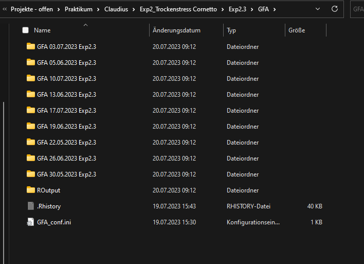

Example folder structure. The names of the folders do not matter. Note the file ‘GFA_conf.ini’ in the directory. This file is responsible for the behaviour of the script and is necessary to run it. The script will load all data-files (‘*.xlsx’ or ’*.csv’) within the directory the ‘.ini’-file resides in, including any and all subdirectories. You could even put all your data files into the same folder as your config.

Below you will find an example script:

```r
# do not run, show
get_os <- function(){
    sysinf <- Sys.info()
    if (!is.null(sysinf)){
        os <- sysinf['sysname']
        if (os == 'Darwin')
            os <- "osx"
    } else { ## mystery machine
        os <- .Platform$OS.type
        if (grepl("^darwin", R.version$os))
            os <- "osx"
        if (grepl("linux-gnu", R.version$os))
            os <- "linux"
    }
    return(tolower(os))
}
source("D:/Dokumente neu/Repositories/Grünflächen-Utilities/GFA_Evaluation.R")
if (isTRUE(as.logical(get_os()=='windows'))) { # this is an optimistic approach to the problem, I won't try to anticipate all possible OS-names # WINDOWS:
    GFA_2 <- GFA_main(folder_path = r"(D:\Dokumente neu\Obsidian NoteTaking\The Universe\200 University\06 Interns and Unis\BE28 Internship Report\assets\Exp2.3\GFA\GFA_conf.ini)",returnDays = 1,saveFigures = 0,saveExcel = 0,saveRDATA = 0)
} else {    # MAC:
    GFA_2 <- GFA_main(folder_path = r"(D:\Dokumente neu\Obsidian NoteTaking\The Universe\200 University\06 Interns and Unis\BE28 Internship Report\assets\Exp2.3\GFA\GFA_conf.ini)",returnDays = 1,saveFigures = 0,saveExcel = 0,saveRDATA = 0)
}
## do not clear your workspace between the calls to `source()` and `GFA_main()`. If you absolutely MUST, only clear your worspace after GFA_main() has returned its output and you no longer need its results, or selectively clear variables. Clearing the workspace inbetween these two points will render the script useless.
```

Which results in the following plot:

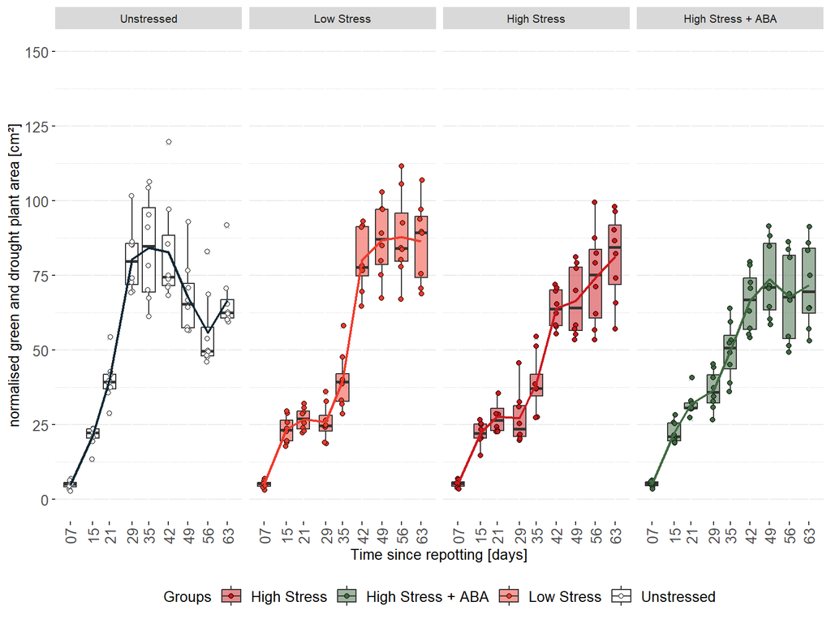

Based on these configuration settings:

```r
library(readr)
library(stringr)
text_file <- GFA_2[[6]]
enc <- guess_encoding(text_file)[[1]][[1]]
file_string <- str_c(readLines(con <- file(text_file, encoding = enc)),collapse = "  \n")
mycat <- function(text){
  return(cat(gsub(pattern = "\n", replacement = "  \n", x = text)))
}
str <- mycat(file_string)
```

```
[Experiment]
BreakStepSize=25
Facet2D=FALSE
Facet2DVar=
figure_date_format=%d.%m.%Y
filename_date_format=%d.%m.%Y
Filename_Prefix=GF2.3
ForceAxes=TRUE
GroupsOrderX=Unstressed,Low Stress,High Stress,High Stress + ABA
GroupsOrderY=
Name=EX5: Experiment 2 Grünfläche
Normalise=FALSE
Palette_Boxplot=#CB181D,#406a41,#EF3B2C,white
Palette_Boxplot2=white,#EF3B2C,#CB181D,#406a41,
Palette_Lines=#CB181D,#406a41,#EF3B2C,#112734,
Palette_Lines2=#112734,#EF3B2C,#CB181D,#406a41,
PotsPerGroup=8
RefGroup=Unstressed
T0=15.05.2023
UniqueGroups=High Stress,High Stress + ABA,Low Stress,Unstressed
used_plant_area=plant_area_normalised
XLabel=Time since repotting
XLabel_Daily=Treatment Groups
YLabel=normalised green and drought plant area
YLimits=0,125
[Fontsizes]
Fontsize_General=10.000000
Fontsize_LegendText=10.000000
Fontsize_LegendTitle=10.000000
Fontsize_PValue=2.500000
Fontsize_SampleSize=2.500000
Fontsize_XAxisLabel=10.000000
Fontsize_XAxisTicks=10.000000
Fontsize_YAxisLabel=10.000000
Fontsize_YAxisTicks=10.000000
[General]
axis_units_x=Tage,days
axis_units_x_Daily=Tage,days
axis_units_y=cm²,cm²
axis_units_y_Daily=cm²,cm²
Debug=FALSE
DebugText=Setting [DEBUG==TRUE] in section '2. General Configuration' will overwrite any settings made in this section
language=English
PlotMeanLine=TRUE
PlotSampleSize=TRUE
RelativeColnames=TRUE
ShowBothColnames=FALSE
ShowNAtallboxplots=TRUE
ShowOnlyIrregularN=TRUE
ShowTitle=FALSE
ShowTitle_Daily=FALSE
ShowTitleDateWhere=SubTitle
ShowTitleSub=FALSE
ShowTitleSub_Daily=FALSE
Theme=6
Title=Title
Title_Daily=Title_Daily
TitleSub=TitleSub
TitleSub_Daily=TitleSub_Daily
used_filesuffix=xlsx
```

**Naming Requirements on input csv- and xlsx-files**

In order for the R-Script to calculate the time since T0 correctly, input files must contain the respective date in their **filename**.  
Formats allowed are `%Y-%m-%d` (2023-12-20) and `%d.%m.%Y` (20.12.2023).

## 2.2 Error Handling and restrictions

Most aspects of the R-Script are handled on a trust-first basis, but certain things are validated as required. If checks are not passed, the script will stop by throwing a distinct *error*-message (red text in Console). In this case, the issue *must* be resolved to allow the script to function.  
There are also notifications which are displayed as *warnings* (yellow text). These contain information on internal deviations to the given configurations, or generally to inform the user that something might behave different than the settings would indicate. The difference here is that they are performed automatically, are conservative and usually required to obtain acceptable results.

```r
Error: GFA_main() [user-defined]: Task: loading configuration from ini-file,1
The configuration file ('C:\Users\USER REDACTED\Desktop\TempTemporal\Exp2.3_GFA_fixedValuesfor1007\GFA_conf.ini')
could not be loaded. The best assumption for its file-encoding is UTF-16LE, but using this returned an empty object.
Please double-check the encoding of the configuration-file
```

Beyond this, by functionality this script does not deviate from the steps taken in the original script this was derived from.

## 2.3 Additional functions bundled in the R-Script

The R-script contains a couple of quality-of-life utilities to allow for easier handling of the generated data.  
Namely, 3 functions exist to calculate relative and absolute changes *inbetween dates*.  
Each function is described in more detail below.

*These functions are saved when the data is saved to the `*.RData`-file.* As a consequence, you can load them in without having to source the entire codebase again:

```r
old <- getAbsolute_change(1212,21) ## use the originally loaded instance
rm(getAbsolute_change) ## remove it to illustrate the loading from object
getAbsolute_change <- GFA_2[[9]] ## load the function back from the results-object
new <- getAbsolute_change(1212,21) ## and run it again to show it's the same
```

```r
kable(old,caption = "Execution using the old, initially loaded version of the function, which was loaded when generating the results initially.")
```

| x |
| --- |
| 1191 |

Execution using the old, initially loaded version of the function, which was loaded when generating the results initially.

```r
kable(new,caption = "Execution using the newly loaded version of the function")
```

| x |
| --- |
| 1191 |

Execution using the newly loaded version of the function

### 2.3.1 getRelative_change() & getAbsolute_change()

The two functions `getRelative_change()` & `getAbsolute_change()` will return the relative gain (expressed as percent *added to the 100% base*) or absolute gain for each group between two dates.

*Examples*:  
Get absolute change between two dates:  
`abs_change <- getAbsolute_change(this = "2023-07-17",last = "2023-05-22",Object = GFA_2[[3]])`:

```r
kable(abs_change <- getAbsolute_change(this = "2023-07-17",last = "2023-05-22",Object = GFA_2[[3]],T),caption = "Absolute change between 2 different dates.")
```

| Groups | Last mean | abs. Change [cm^2] | this mean |
| --- | --- | --- | --- |
| High Stress | 5.13556645899076 | 76.1784689159783 | 81.314035374969 |
| High Stress + ABA | 5.13370482447878 | 66.5990667263945 | 71.7327715508733 |
| Low Stress | 5.04207659262398 | 81.4506955850396 | 86.4927721776635 |
| Unstressed | 4.94122570961151 | 61.7609586654564 | 66.702184375068 |

Absolute change between 2 different dates.

Get relative change between two dates:  
`rel_change <- getRelative_change(this = "2023-07-17",last = "2023-05-22",Object = GFA_2[[3]])`

```r
kable(rel_change <- getRelative_change(this = "2023-07-17",last = "2023-05-22",Object = GFA_2[[3]],T),caption = "Relative change between 2 different dates.")
```

| Groups | Last mean | rel. Change [%] | this mean |
| --- | --- | --- | --- |
| High Stress | 5.13556645899076 | 1483.35085378194 | 81.314035374969 |
| High Stress + ABA | 5.13370482447878 | 1297.29053390124 | 71.7327715508733 |
| Low Stress | 5.04207659262398 | 1615.41964087164 | 86.4927721776635 |
| Unstressed | 4.94122570961151 | 1249.91170804687 | 66.702184375068 |

Relative change between 2 different dates.

You may additionally calculate the change between arbitrary *numeric values*. This means you can compare different groups at the same date, or different groups on different dates[^4], or really just any two arbitrary length-1 numerics:

<sup>4</sup> Not sure there would be a use-case for that, but technically it is doable.

```r
kable(abs_change_between_groups <- getAbsolute_change(GFA_2[[3]]$"2023-07-03"$Res$summary$mean[[1]],GFA_2[[3]]$"2023-07-03"$Res$summary$mean[[4]],F,T),caption="Comparing the means of two different groups of the same date, in terms of absolute change.")
```

| Last mean | abs. Change [cm^2] | this mean |
| --- | --- | --- |
| 67.7975960106527 | -1.32108630688019 | 66.4765097037725 |

Comparing the means of two different groups of the same date, in terms of absolute change.

### 2.3.2 calculateChange()

This is essentially a special wrapper around both `getRelative_change()` & `getAbsolute_change()`. It will print the absolute and relative changes of a group between subsequent dates: `kable(change <- calculateChange(GFA_2[[3]],unlist(GFA_2[[4]]),T),caption="Comparing the means of two different groups of the same date, in terms of absolute change")`

```r
kable(change <- calculateChange(GFA_2[[3]],unlist(GFA_2[[4]]),T,GFA_2[[5]]),caption="Calculate the consecutive absolute and relative changes within each groups across all days.")
```

| Time | Groups | Last mean [cm^2] | abs. Change [cm^2] | rel. Change [%] | this mean [cm^2] |
| --- | --- | --- | --- | --- | --- |
| 2023-05-22 -> 2023-05-30 | High Stress | 5.13556645899076 | 16.9719313310099 | 330.478272777435 | 22.1074977900007 |
| 2023-05-22 -> 2023-05-30 | High Stress + ABA | 5.13370482447878 | 17.2445634313568 | 335.908744677537 | 22.3782682558356 |
| 2023-05-22 -> 2023-05-30 | Low Stress | 5.04207659262398 | 18.3424795396587 | 363.788197237856 | 23.3845561322826 |
| 2023-05-22 -> 2023-05-30 | Unstressed | 4.94122570961151 | 16.2244990955608 | 328.349685868456 | 21.1657248051723 |
| 2023-05-30 -> 2023-06-05 | High Stress | 22.1074977900007 | 5.5400868270463 | 25.0597642468254 | 27.647584617047 |
| 2023-05-30 -> 2023-06-05 | High Stress + ABA | 22.3782682558356 | 9.50707307093388 | 42.4835065977668 | 31.8853413267695 |
| 2023-05-30 -> 2023-06-05 | Low Stress | 23.3845561322826 | 3.49281128061392 | 14.936401875048 | 26.8773674128966 |
| 2023-05-30 -> 2023-06-05 | Unstressed | 21.1657248051723 | 18.8018526237712 | 88.8316029658319 | 39.9675774289435 |
| 2023-06-05 -> 2023-06-13 | High Stress | 27.647584617047 | -0.391548990748273 | -1.41621409671661 | 27.2560356262987 |
| 2023-06-05 -> 2023-06-13 | High Stress + ABA | 31.8853413267695 | 4.66024369711635 | 14.6156305788197 | 36.5455850238858 |
| 2023-06-05 -> 2023-06-13 | Low Stress | 26.8773674128966 | -1.04308342496112 | -3.88089878348956 | 25.8342839879354 |
| 2023-06-05 -> 2023-06-13 | Unstressed | 39.9675774289435 | 40.5769246152565 | 101.524603755122 | 80.5445020442 |
| 2023-06-13 -> 2023-06-19 | High Stress | 27.2560356262987 | 11.5728046992184 | 42.4596036558304 | 38.8288403255171 |
| 2023-06-13 -> 2023-06-19 | High Stress + ABA | 36.5455850238858 | 13.2598804909813 | 36.283125532988 | 49.8054655148672 |
| 2023-06-13 -> 2023-06-19 | Low Stress | 25.8342839879354 | 13.9525761602628 | 54.0079847646584 | 39.7868601481982 |
| 2023-06-13 -> 2023-06-19 | Unstressed | 80.5445020442 | 3.77984573096913 | 4.6928662230662 | 84.3243477751692 |
| 2023-06-19 -> 2023-06-26 | High Stress | 38.8288403255171 | 25.1768857473119 | 64.8406842343072 | 64.005726072829 |
| 2023-06-19 -> 2023-06-26 | High Stress + ABA | 49.8054655148672 | 16.6514023203814 | 33.4328816089689 | 66.4568678352486 |
| 2023-06-19 -> 2023-06-26 | Low Stress | 39.7868601481982 | 40.55230590518 | 101.923865703729 | 80.3391660533782 |
| 2023-06-19 -> 2023-06-26 | Unstressed | 84.3243477751692 | -1.52161284671232 | -1.80447627151453 | 82.8027349284569 |
| 2023-06-26 -> 2023-07-03 | High Stress | 64.005726072829 | 2.47078363094356 | 3.86025404685227 | 66.4765097037725 |
| 2023-06-26 -> 2023-07-03 | High Stress + ABA | 66.4568678352486 | 7.29644205955582 | 10.9792144848659 | 73.7533098948044 |
| 2023-06-26 -> 2023-07-03 | Low Stress | 80.3391660533782 | 6.43746863353861 | 8.01286464594553 | 86.7766346869168 |
| 2023-06-26 -> 2023-07-03 | Unstressed | 82.8027349284569 | -15.0051389178041 | -18.1215498869317 | 67.7975960106527 |
| 2023-07-03 -> 2023-07-10 | High Stress | 66.4765097037725 | 7.58466270231736 | 11.4095381001734 | 74.0611724060899 |
| 2023-07-03 -> 2023-07-10 | High Stress + ABA | 73.7533098948044 | -6.00558684252837 | -8.14280315160668 | 67.747723052276 |
| 2023-07-03 -> 2023-07-10 | Low Stress | 86.7766346869168 | 1.14315904725298 | 1.31735812454286 | 87.9197937341698 |
| 2023-07-03 -> 2023-07-10 | Unstressed | 67.7975960106527 | -11.9539136534125 | -17.6317662525 | 55.8436823572402 |
| 2023-07-10 -> 2023-07-17 | High Stress | 74.0611724060899 | 7.25286296887913 | 9.79307069176607 | 81.314035374969 |
| 2023-07-10 -> 2023-07-17 | High Stress + ABA | 67.747723052276 | 3.98504849859727 | 5.882188092908 | 71.7327715508733 |
| 2023-07-10 -> 2023-07-17 | Low Stress | 87.9197937341698 | -1.42702155650625 | -1.62309475022305 | 86.4927721776635 |
| 2023-07-10 -> 2023-07-17 | Unstressed | 55.8436823572402 | 10.8585020178278 | 19.444459175103 | 66.702184375068 |

Calculate the consecutive absolute and relative changes within each groups across all days.

## 2.4 Execution Time

**Note**

This script was not designed to be particularly performant, but to be robust. The code is not parallelised. That being said, runtime is acceptable for relatively common sizes. Loading, calculation and writing to disk takes ~16 seconds for 10 dates of 6 groups a 7 pots.

## 2.5 Command Line Interface

This utility can be automated via the *rscript*-commandline. While figures cannot be rendered from the command line, this allows further automation.

```r
#|label: gfa_evaluation-help
#|echo: FALSE
library(stringr)
library(optparse)
option_list <- list(
        make_option(c("-i", "--input"),
            type = "character", default = NULL, metavar = "filepath",
            help = "Full path to configuration File."
        ),
        make_option(c("-d", "--returnDays"),
            type = "integer", default = 0,
            help = "pseudo-boolean Flag, either numerical 1 or 0 [Default: %default].\n\t\tToggles execution of per-day analyses", metavar = "[integer]"
        ),
        make_option(c("-f", "--saveFigures"),
            type = "integer", default = 0,
            help = "pseudo-boolean Flag, either numerical 1 or 0 [Default: %default].\n\t\tToggles whether or not figures generated are saved to disk or not. Files are saved to a subfolder relative to configuration file supplied via the option '-i'", metavar = "[integer]"
        ),
        make_option(c("-e", "--saveExcel"),
            type = "integer", default = 0,
            help = "pseudo-boolean Flag, either numerical 1 or 0 [Default: %default].\n\t\tToggles whether or not statistical evaluation and results generated are saved to disk as an '.xlsx'-file or not. Files are saved to a subfolder relative to configuration file supplied via the option '-i'", metavar = "[integer]"
        ),
        make_option(c("-r", "--saveRDATA"),
            type = "integer", default = 0,
            help = "pseudo-boolean Flag, either numerical 1 or 0 [Default: %default].\n\t\tToggles whether or not all generated data (plots, loaded configuration data, relevant evaluation functions) are saved to an '.RData'-file or not. Files are saved to a subfolder relative to configuration file supplied via the option '-i'", metavar = "[integer]"
        ),
        make_option(c("-w", "--warning"),
            type = "integer", default = 1,
            help = "numerical Flag, between -1<=x<=2 [Default: %default].\n\n\t\tIt is not recommended to change the default value if the results are unknown and not validated,\n\t\tinstead it is recommended to only mute all warnings if the calculation must be repeated and the console output is supposed to be as clean as possible. Does not affect errors.\n\n\t\t-1:\tAll Warnings are ignored and will not be printed\n\t\t 0:\tWarnings will print after top-level function has completed.\n\t\t 1:\tWarnings are printed as they occur.\n\t\t 2:\tTreat all warnings as errors."
        ),
        make_option(c("-c", "--overwriteEncoding"),
            type = "character", default = "UTF-16LE",
            help = "string [Default: %default].\n\t\tManual override for forcing a different file-encoding when loading in the configuration file.\n\t\tOnly use when necessary, and if the automatic encoding detection failed. This argument must be provided if the configuration-file supplied via the option '-i' was saved with an encoding DIFFERENT than 'UTF-16LE'", metavar = "[string]"
        ),
        make_option(c("-l", "--strictLimits"),
            type = "integer", default = 0,
            help = "pseudo-boolean Flag, either numerical 1 or 0 [Default: %default].\n\t\tManual override for forcing _exactly_ the Y-limits defined in configuration, fully disabling any precautionary adjustments against overlapping elements. Primarily used if dimensions are known and the user only wants to rerun.", metavar = "[integer]"
        ),
        make_option(c("-m", "--strictLimitsDaily"),
            type = "integer", default = 0,
            help = "pseudo-boolean Flag, either numerical 1 or 0 [Default: %default].\n\t\tAnalogue for daily Plots. See flag '-l' for further details.", metavar = "[integer]"
        )

    )
    Object_Key <- str_c("", "Object Key", "1: Summary Plot", "2: Titles", "3: Daily Analyses", "4: Dates", "5: configuration", "6: configuration-path", "7: RDATA_Path", "8: function 'getRelative_change()'", "9: function 'getAbsolute_change()'", "10: function\t 'formatPValue()'", sep = "\n")
    retDocs <- str_c("return\t\t\t\t\t\t Object containing the following elements\t\t\t\t\t\t\t\t [list]",
        "return[[1]]\t\t\t\t\t Summary-Plot displaying progression over time\t\t\t\t\t\t\t\t [ggplot]",
        "return[[2]]\t\t\t\t\t plot_title, plot_subtitle, min age and max age\t\t\t\t\t\t\t\t [list]",
        "return[[3]]\t\t\t\t\t Daily Analyses\t\t\t\t\t\t\t\t\t\t\t\t [list]",
        "\t$'dd.mm.YYYY' \t\t\t\t Day-Object containing all results for a specified date, f.e. return[[3]]$'30.05.2023'\t\t\t [list]",
        "\t\t$boxplot\t\t\t figure for the date. contains p-values and sample-sizes\t\t\t\t\t\t [ggplot]",
        "\t\t$Outlierplot\t\t\t rudimentary outlier-plot. Outliers are marked red.\t\t\t\t\t\t\t [ggplot]",
        "\t\t$Res\t\t\t\t all statistical data for a given date\t\t\t\t\t\t\t\t\t [list]",
        "\t\t\t $Data\t\t\t data loaded IN from the respective Excel-Sheet.\t\t\t\t\t\t\t [tbl_df]",
        "\t\t\t $Outlier\t\t returns outliers as identified via 'identify_outliers()' (rstatix)\t\t\t\t\t [tbl_df]",
        "\t\t\t $data_wo_Outliers\t returns data minus the outliers present in $Outlier\t\t\t\t\t\t\t [tbl_df]",
        "\t\t\t $Norm\t\t\t Result of the Normality-Tests\t\t\t\t\t\t\t\t\t\t [list]",
        "\t\t\t $BT\t\t\t Result of the Bartlett-Tests\t\t\t\t\t\t\t\t\t\t [list]",
        "\t\t\t $T.Test  \t\t Result of the T.Tests\t\t\t\t\t\t\t\t\t\t\t [list]",
        "\t\t\t $summary \t\t Result of the 'summary'-Command\t\t\t\t\t\t\t\t\t [list].\n\t\t\t\t\t\t NOTE: Additionally, the absolute [cm^2] and relative [%] change relative to\n\t\t\t\t\t\t the previous measuring-date is printed for measurement dates 2+.",
        "return[[4]] \t\t\t\t\t returns the dates in ISO-format\t\t\t\t\t\t\t\t\t [Date]",
        "return[[5]] \t\t\t\t\t configuration used during execution, as loaded from the configuration path provided.\t\t\t [list]",
        "return[[6]] \t\t\t\t\t path to the configuration-file loaded\t\t\t\t\t\t\t\t\t [string]",
        "return[[7]] \t\t\t\t\t path to the RDATA-file containing this object (if saveRDATA=1, otherwhise this path does not exist)\t [string]",
        "return[[8]]  - getRelative_change\t\t refer to documentation for details\t\t\t\t\t\t\t\t\t [function]",
        "return[[9]]  - getAbsolute_change\t\t refer to documentation for details\t\t\t\t\t\t\t\t\t [function]",
        "return[[10]] - formatPValue\t\t\t refer to documentation for details\t\t\t\t\t\t\t\t\t [function]",
        sep = "\n"
    )
    opt_parser = OptionParser(option_list=option_list,epilogue = str_c("returnValue 'return':\n",retDocs),usage = "rscript path\\to\\GFA_Evaluation.R [options]");
print_help(opt_parser)
```

```
Usage: rscript path\to\GFA_Evaluation.R [options]


Options:
    -i FILEPATH, --input=FILEPATH
        Full path to configuration File.

    -d [INTEGER], --returnDays=[INTEGER]
        pseudo-boolean Flag, either numerical 1 or 0 [Default: 0].
        Toggles execution of per-day analyses

    -f [INTEGER], --saveFigures=[INTEGER]
        pseudo-boolean Flag, either numerical 1 or 0 [Default: 0].
        Toggles whether or not figures generated are saved to disk or not. Files are saved to a subfolder relative to configuration file supplied via the option '-i'

    -e [INTEGER], --saveExcel=[INTEGER]
        pseudo-boolean Flag, either numerical 1 or 0 [Default: 0].
        Toggles whether or not statistical evaluation and results generated are saved to disk as an '.xlsx'-file or not. Files are saved to a subfolder relative to configuration file supplied via the option '-i'

    -r [INTEGER], --saveRDATA=[INTEGER]
        pseudo-boolean Flag, either numerical 1 or 0 [Default: 0].
        Toggles whether or not all generated data (plots, loaded configuration data, relevant evaluation functions) are saved to an '.RData'-file or not. Files are saved to a subfolder relative to configuration file supplied via the option '-i'

    -w WARNING, --warning=WARNING
        numerical Flag, between -1<=x<=2 [Default: 1].

        It is not recommended to change the default value if the results are unknown and not validated,
        instead it is recommended to only mute all warnings if the calculation must be repeated and the console output is supposed to be as clean as possible. Does not affect errors.

        -1: All Warnings are ignored and will not be printed
         0: Warnings will print after top-level function has completed.
         1: Warnings are printed as they occur.
         2: Treat all warnings as errors.

    -c [STRING], --overwriteEncoding=[STRING]
        string [Default: UTF-16LE].
        Manual override for forcing a different file-encoding when loading in the configuration file.
        Only use when necessary, and if the automatic encoding detection failed. This argument must be provided if the configuration-file supplied via the option '-i' was saved with an encoding DIFFERENT than 'UTF-16LE'

    -l [INTEGER], --strictLimits=[INTEGER]
```

[output cut: 20 more lines]

```
             $Outlier        returns outliers as identified via 'identify_outliers()' (rstatix)                  [tbl_df]
             $data_wo_Outliers   returns data minus the outliers present in $Outlier                             [tbl_df]
             $Norm           Result of the Normality-Tests                                       [list]
             $BT             Result of the Bartlett-Tests                                        [list]
             $T.Test         Result of the T.Tests                                           [list]
             $summary        Result of the 'summary'-Command                                     [list].
                         NOTE: Additionally, the absolute [cm^2] and relative [%] change relative to
                         the previous measuring-date is printed for measurement dates 2+.
return[[4]]                      returns the dates in ISO-format                                     [Date]
return[[5]]                      configuration used during execution, as loaded from the configuration path provided.            [list]
return[[6]]                      path to the configuration-file loaded                                   [string]
return[[7]]                      path to the RDATA-file containing this object (if saveRDATA=1, otherwhise this path does not exist)     [string]
return[[8]]  - getRelative_change        refer to documentation for details                                  [function]
return[[9]]  - getAbsolute_change        refer to documentation for details                                  [function]
return[[10]] - formatPValue          refer to documentation for details                                  [function]
```

### 2.5.1 Setup

Using the script as a command line utility requires that RScript is accessible. On Windows, this is done by either

1. adding the path to RScript.exe’s *directory* to the Users’ Environment PATH Variable.
2. providing the full path to RScript.exe:

```
"C:/Users/Claudius Main/AppData/Local/Programs/R/R-4.2.3/bin/x64/Rscript.exe" "D:/Dokumente neu/Repositories/Grünflächen-Utilities/GFA_Evaluation.R" [options]
```

**Important**

Note that this requires some advanced knowledge on system environment and environment variables. Additionally, mistakes during this process have the chance of disrupting various tools, and can in the worst case brick your PC.

Be careful when editing the PATH-variable. Doing so erroneously can result in your system getting fully bricked. If unsure, refer to related documentation.

A simple guide for Windows can be found here.  
For Mac, refer to [here](https://www.educative.io/answers/how-to-add-python-to-the-path-variable-in-mac). The process is the same, merely for a different executable.

After doing so, the user can run

```
rscript "D:/Dokumente neu/Repositories/Grünflächen-Utilities/GFA_Evaluation.R" [options]
```

When using the shell started via the program’s tray menu (cf. here), the path to the `GFA_Evaluation.R` can be omitted:

```
rscript GFA_Evaluation.R [options]
```

When a configuration-file is selected already (cf. here), the following barebones command-line string is copied to the clipboard:

```
rscript gfa_evaluation.r -i  "path/to/configurationfile.ini"
```

## 2.6 Decision Tree for statistical tests

Statistical tests are only evaluated on a per-day basis. Which tests get executed is controlled by the following logic:

1. Normality is detected across all groups present in the outlier-less dataset `wo_outliers` by using the `shapiro.test()`:[^5]

<sup>5</sup> When `Facet2D==TRUE`, the dataset is grouped by `Data$Interactions`, which in turn is defined within `RunDetailed()` as `Data$interactions <- interaction(Data$Gruppe, Data$Facet)`

```r
norm <- wo_outliers %>%
  group_by(Gruppe) %>%
  dplyr::summarise(
    statistic = shapiro.test(plant_area_plotted)$statistic,
    p.value = shapiro.test(plant_area_plotted)$p.value
)
```

2. Afterwards, the function `isNormallyDistribured(norm)` tests if *all groups* satisfy the condition $\text{p-value}>\text{Threshold}$, where $\text{Threshold}=0.05$.

```r
isNormallyDistributed <- function(norm_obj, Threshold = 0.05) {
    # Function überprüft, wie viele der Gruppen den Test zur Normalverteilung bestehen. Wenn alle ihn bestehen, gibt sie als boolean TRUE zurück

    boolean <- ""
    Count <- dim(norm_obj)[1]
    ThresholdPassing <- subset(norm_obj, subset = p.value > Threshold) # Get the entries which fulfill the Threshold.
    Count_Threshold <- dim(ThresholdPassing)[1]
    boolean <- (Count == Count_Threshold) # Evaluate threshold comparison
    return(boolean)
  }
```

In simple terms: If a single groups reports a p-value smaller than `Threshold`, the dataset is flagged as **not** conforming to a normal distribution. If all groups have a p-value greater than `Threshold`, the dataset is assumed to conform to a normal distribution.  
There are now two cases:

- Normality is assumed - the following tests are performed:

```r
BT <- bartlett.test(plant_area_plotted ~ Gruppe, wo_outliers)
BT <- do.call("rbind", BT)
BT <- data.frame(names = row.names(BT), BT)

Data_stat_test <- subset(Data, select = -c(file))
Data_stat_test <- cbind(Data_stat_test, Data$file) # this makes no sense, but       not removing and re-adding the file-column causes the stat-test to fail
Data_stat_test$Group <- as.character(Data_stat_test$Gruppe)
stat.test <- Data_stat_test %>%
  t_test(plant_area_plotted ~ Gruppe, var.equal = TRUE, alternative =       "two.sided", ref.group = ini$Experiment$RefGroup) %>%
  add_significance("p") %>%
  add_xy_position(x = "Gruppe")
```

- Normality is not assumed - the following tests are performed:

```r
levene <- leveneTest(wo_outliers$plant_area_plotted, wo_outliers$Gruppe)

Data_stat_test <- subset(Data, select = -c(file))
Data_stat_test <- cbind(Data_stat_test, Data$file) # this makes no sense, but      not removing and re-adding the file-column causes the stat-test to fail
stat.test <- Data_stat_test %>%
  wilcox_test(plant_area_plotted ~ Gruppe, alternative = "two.sided",      paired = FALSE, ref.group = ini$Experiment$RefGroup) %>%
  add_significance("p") %>%
  add_xy_position(x = "Gruppe")
```

# 3 Updating the utility

By default, the program checks for updates at startup, presuming a stable internet-connection is established. If a new main release is detected, the user is given the option to update their instance.  
The user may decide whether or not they are notified for updates to the development version of the program, instead of the more stable release. By default, the program checks for stable updates.

**Potential loss of data**

When downloading a new release, the configuration of your current release does not carry over.  
It is therefore recommended to make a backup of your configuration file, which is located at `<Location of Program>\INI-Files\GFA-Grünflächen-Configurator.ini`.

The second configuration-file (`<Location of Program>\INI-Files\GFC_DA.ini`) contains the information required to generate the section `1. Configuration File` of the Configurator-GUI. **Unless manually modified (refer to here)** it is not recommended nor necessary to migrate the old file onto the new version.

If you defined non-standard controls via the aforementioned configuration-file, these parts should be manually migrated to the new configuration file. This process includes starting the configurator once and exiting it again once the GUI shows. After this, the user may modify the `GFC_DA.ini`-file to re-add their own modifications.

# 4 Requirements

Full functionality requires:

- `GFA-Grünflächen-Configurator`:
  - the program/user must have read- & write-access to
    - the program’s own location
    - the location of any configuration file generated or modified with this program
  - Program must be run on a windows operating system.

**Important**

Alternatively, [AutoHotKey v.1.1](https://www.autohotkey.com) can be installed to use the uncompiled script version of the utility. That way, the script could be modified beyond the scope of its configuration.  
Note that antivirus- and antimalware-programs *love* to flag AHK as malicious, regardless of whether or not it is ran as a compiled executable or as a script-file via an installed Autohotkey-executable. However, AHK is not a malicious software by heart. Malicious actions can be performed by the author of a *script*, but that is arguably true for any scripting/programming language one runs on their system.  
This is a known issue, see [the documenation on AHK](https://www.autohotkey.com/docs/v1/FAQ.htm#Virus),[this megathread on AHK’s forum board](https://www.autohotkey.com/boards/viewtopic.php?f=17&t=62266), and [for good measure Wikipedia links to a couple more threads](https://en.wikipedia.org/wiki/AutoHotkey#Malware).

- `csv2xlsx`: Requires installation of Microsoft Excel. Will not function instead.
  - as a submodule of the above-mentioned configurator, it requires the same access rights.
- `GFA_Evaluation.R`: Installation of R, and respectively required packages (will be loaded by the R-script via `library`) - usable on any operating system

# 5 License and licenses of used code

See accompanying license file. Licenses of used code can be found in `<Location of Program>\res\CombinedLicenses.txt`, as best as could be retrieved.